# Eksplorasi Data Iris dengan MySQL, PostgreSQL, dan Power BI

## 1. Pendahuluan

Dataset **Iris** adalah dataset klasik dalam analisis data dan pembelajaran mesin. Dataset ini terdiri dari 150 baris dengan 4 atribut numerik:

- Sepal Length
- Sepal Width
- Petal Length
- Petal Width

Serta 1 atribut kategori yaitu `species` (*Setosa, Versicolor, Virginica*).

### Tujuan Proyek

1. Membuat database Iris di **MySQL** dan **PostgreSQL**.
2. Menghubungkan database tersebut dengan **Power BI**.
3. Melakukan analisis deskriptif berupa min, max, dan rata-rata setiap atribut.
4. Menampilkan distribusi jumlah data setiap kelas dalam bentuk grafik batang.

## 2. Database

### Struktur Database

```
CREATE DATABASE iris_db;

USE iris_db;

CREATE TABLE iris (
    id INT AUTO_INCREMENT PRIMARY KEY,
    sepal_length FLOAT,
    sepal_width FLOAT,
    petal_length FLOAT,
    petal_width FLOAT,
    species VARCHAR(20)
);
```

## 2. Database MySQL dan Postgresql menggunakan Aiven

Untuk membuat cloud database kita bisa menggunakan website aiven yang memberikan akses free dalam membuat sebuah database baik Mysql maupun Postgresql,dan berikut informasi dari database yang saya buat:

### Informasi Koneksi Mysql

- **Hostname**: `mysql-fc1c646-asepprayogi716-30a1.d.aivencloud.com`
- **Port**: `16395`
- **Username**: `avnadmin`
- **Password**: `AVNS_AHAxpuoiPjhYJmRGcpt`
- **Database**: `defaultdb`

### Informasi Koneksi Postgresql

- **URL**: `psql 'postgres://avnadmin:AVNS_0Vt8kHasY9r-5ywzxgc@pg-2c0f83d0-asepprayogi716-30a1.d.aivencloud.com:16395/defaultdb?sslmode=require'`
- **Hostname**: `pg-2c0f83d0-asepprayogi716-30a1.d.aivencloud.com`
- **Port**: `16395`
- **Username**: `avnadmin`
- **Password**: `AVNS_0Vt8kHasY9r-5ywzxgc`
- **Database**: `defaultdb`

### Proses connect Postgresql di DBeaver

1. Buka DBeaver → New Database Connection → pilih **MySQL/Postgrasql**.
2. Masukkan hostname, port, username, dan password(mysql dan postgresql).postgresql juga bisa menggunakan url seperti yang sudah dilampirkan pada informasi koneksi diatas
3. Buat database baru `iris_db`.
4. Buat tabel dengan struktur sesuai dataset yaotu data iris.

## 3. Integrasi Database ke Power BI

1. Buka Power BI Desktop.
2. Pilih **Get Data → MySQL Database** atau **PostgreSQL Database**.
3. Masukkan hostname, port, username, dan password sesuai konfigurasi.
4. Pilih database `iris_db` dan tabel `iris`.
5. Data siap divisualisasikan.

### **Deskripsi Data**

Dataset Iris adalah dataset klasik dalam analisis data dan pembelajaran mesin. Dataset ini terdiri dari 150 baris dengan 4 atribut numerik:

- Sepal Length
- Sepal Width
- Petal Length
- Petal Width

| Kolom | Tipe Data | Keterangan |
| --- | --- | --- |
| `sepal_length` | FLOAT/REAL | Panjang sepal dalam cm |
| `sepal_width` | FLOAT/REAL | Lebar sepal dalam cm |
| `petal_length` | FLOAT/REAL | Panjang petal dalam cm |
| `petal_width` | FLOAT/REAL | Lebar petal dalam cm |
| `species` | VARCHAR | Jenis bunga iris |

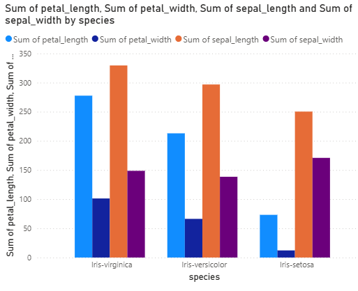

### Interpretasi Warna Batang

- 🟦 **Biru muda** → *Sum of petal_length* (total panjang mahkota)
- 🔵 **Biru tua** → *Sum of petal_width* (total lebar mahkota)
- 🟧 **Oranye** → *Sum of sepal_length* (total panjang kelopak)
- 🟪 **Ungu** → *Sum of sepal_width* (total lebar kelopak)

## Tabel Ringkasan Total/Kolom

| Species | Sum of petal_length | Sum of petal_width | Sum of sepal_length | Sum of sepal_width |
| --- | --- | --- | --- | --- |
| Iris-virginica | 277.60 | 101.30 | 329.40 | 148.70 |
| Iris-versicolor | 213.00 | 66.30 | 296.80 | 138.50 |
| Iris-setosa | 73.20 | 12.20 | 250.30 | 170.90 |

### Hubungan dengan Grafik Batang

- Batang biru muda (*petal_length*) paling tinggi untuk **Virginica** → sesuai dengan nilai 277.60.
- Batang biru tua (*petal_width*) paling rendah untuk **Setosa** → sesuai dengan nilai 12.20.
- Batang ungu (*sepal_width*) tertinggi justru pada **Setosa** (170.90), berbeda dengan pola fitur lainnya.

## **Nilai min-max dari setiap kolom**

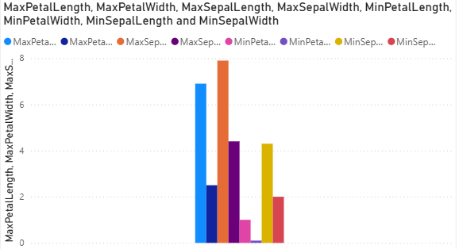

Berikut adalah nilai minimum dan maksimum dari setiap kolom numerik dalam dataset:

| Kolom | Maksimum | Minimum |
| --- | --- | --- |
| `Sepal Length` | 7.90 | 4.30 |
| `Sepal Width` | 4.40 | 2.00 |
| `Petal Length` | 6.90 | 1.00 |
| `Petal Width` | 2.50 | 0.10 |

Grafik batang di atas ini secara visual menunjukkan perbandingan nilai maksimum dan minimum dari fitur-fitur dataset Iris.  
Terlihat bahwa **Sepal Length** memiliki nilai maksimum terbesar, sementara **Petal Width** memiliki nilai minimum terkecil.

### **Nilai Rata-rata dari setiap kolom**

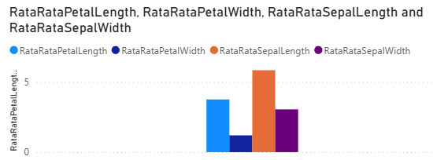

Berikut adalah nilai rata-rata dari setiap kolom dalam dataset:

| Kolom | Rata-rata |
| --- | --- |
| `Sepal Length` | 5.84 |
| `Sepal Width` | 3.05 |
| `Petal Length` | 3.76 |
| `Petal Width` | 1.20 |

Grafik batang di atas ini memperlihatkan perbandingan nilai rata-rata antar fitur pada dataset Iris.  
Terlihat bahwa **Sepal Length** memiliki rata-rata tertinggi, sementara **Petal Width** memiliki rata-rata terendah.

### **Jumlah Setiap kelas**

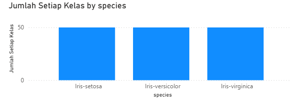

## Distribusi Kelas

Berikut adalah jumlah data pada setiap kelas dalam dataset Iris:

| Species | Jumlah Data |
| --- | --- |
| `Iris-setosa` | 50 |
| `Iris-versicolor` | 50 |
| `Iris-virginica` | 50 |

Grafik batang di atas ini memperlihatkan distribusi jumlah data per kelas.  
Terlihat bahwa setiap kelas (`Iris-setosa`, `Iris-versicolor`, dan `Iris-virginica`) memiliki jumlah data yang **seimbang**, yaitu masing-masing sebanyak **50 data**.